# HomeWork1

Author

Gyte Stakauskaite

Published

March 15, 2026

#1. Downloading tables

```r
library(readr)
count_table <- read_table("count_table.txt",
    skip = 1)
gene_types <- read_table("gene_id_type.tsv",
    col_names = FALSE)
colnames(gene_types) <- c("Gene_ID", "Gene_type")
count_table_clean <- count_table[, -c(2:6)]
colnames(count_table_clean) <- c("Gene_ID", "SRR11647686", "SRR11647688", "SRR11647690", "SRR11647696", "SRR11647698", "SRR11647700")

library(readxl)
coldata_BDA <- read_xlsx("coldata_BDA.xlsx")
coldata_BDA <- as.data.frame(coldata_BDA)
rownames(coldata_BDA) <- coldata_BDA$Sample
coldata_BDA$Type <- as.factor(coldata_BDA$Type)
```

#2. Sorting for protein coding and making a matrix

```r
combined_table <- merge(gene_types, count_table_clean, by = "Gene_ID")
protein_coding <- combined_table[combined_table$Gene_type == "protein_coding", ]
counts_protein_coding <- protein_coding[, -2]
rownames(counts_protein_coding) <- counts_protein_coding$Gene_ID
counts_protein_coding <- counts_protein_coding[, -1]
```

#3. deseq2 and shrinkage

```r
library(DESeq2)

dds_BDA <- DESeqDataSetFromMatrix(
  countData = counts_protein_coding,
  colData = coldata_BDA,
  design = ~ Type
)

dds_BDA$Type <- relevel(dds_BDA$Type, ref = "non_tumour")

keep <- rowSums(counts(dds_BDA)) >= 10
dds_BDA <- dds_BDA[keep, ]
cat("Genes remaining after low-count filter:", nrow(dds_BDA), "\n")
```

```
Genes remaining after low-count filter: 16856
```

```r
#pasiliekam eilutes, kur suma eiluteje dauiau nei 10 (nereiksmingas padidejimas klaidina)
#Toliau shrinkage - sumazina grafikuose noise

dds_BDA <- DESeq(dds_BDA)
res_BDA <- results(dds_BDA, contrast = c("Type","tumour","non_tumour"), alpha = 0.05)
summary(res_BDA)
```

```
out of 16856 with nonzero total read count
adjusted p-value < 0.05
LFC > 0 (up)       : 843, 5%
LFC < 0 (down)     : 957, 5.7%
outliers [1]       : 143, 0.85%
low counts [2]     : 0, 0%
(mean count < 1)
[1] see 'cooksCutoff' argument of ?results
[2] see 'independentFiltering' argument of ?results
```

```r
#BiocManager::install("apeglm")
library(apeglm)
res_BDA_shrunk <- lfcShrink(dds_BDA, coef = "Type_tumour_vs_non_tumour", type = "apeglm")
```

#4. Fold change table

```r
library(dplyr)
library(tibble)

res_BDA_df <- res_BDA_shrunk |>
  as.data.frame() |>
  rownames_to_column("gene") |>
  arrange(padj) |>
  mutate(
    significance = case_when(
      padj < 0.05 & log2FoldChange >  1 ~ "Up",
      padj < 0.05 & log2FoldChange < -1 ~ "Down",
      TRUE ~ "NS"  # Not Significant
    ),
    significance = factor(significance, levels = c("Up", "Down", "NS"))
  )
table(res_BDA_df$significance)
```

```
   Up  Down    NS
  819   935 15102
```

```r
#pirmi 10 su didziausiu fold change
cat("\nTop 10 upregulated genes:\n")
```

```
Top 10 upregulated genes:
```

```r
res_BDA_df %>% filter(significance == "Up") %>% head(10) %>%
  dplyr::select(gene, log2FoldChange, padj) %>% print()
```

```
                 gene log2FoldChange         padj
1  ENSG00000123500.10       8.696562 1.269837e-43
2   ENSG00000170373.9       8.870657 1.783472e-35
3  ENSG00000149968.12       8.937970 4.534948e-28
4  ENSG00000060718.23       9.333265 6.563487e-24
5  ENSG00000099953.11       7.198470 6.717680e-20
6  ENSG00000104415.14       3.760091 7.458810e-20
7  ENSG00000133110.16       5.133608 2.152151e-17
8  ENSG00000148848.15       4.673621 6.164352e-15
9  ENSG00000118785.16       6.009083 7.706731e-15
10 ENSG00000108821.15       4.804838 6.771760e-14
```

```r
#diferenciskai ekspresuojami genai su slenksciu ir be slenkscio
deg_no_fc <- res_BDA_df %>%
  filter(padj < 0.05)
write.csv(deg_no_fc, "DEG_no_fold_change.csv", row.names = FALSE)
deg_fc <- res_BDA_df %>%
  filter(padj < 0.05 & abs(log2FoldChange) > 1)
write.csv(deg_fc, "DEG_with_fold_change.csv", row.names = FALSE)
```

#Graphs

#1. Identify total number of reads per sample and number of detected genes.

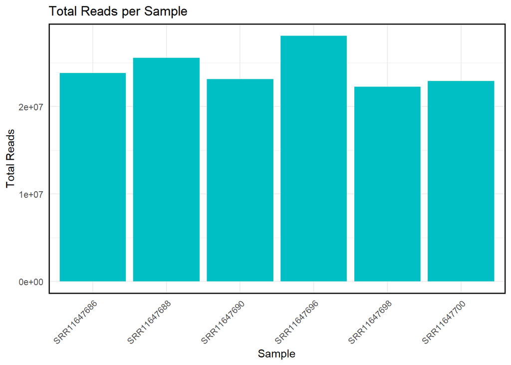

```r
reads_per_sample <- colSums(count_table_clean[, -1])
genes_detected <- colSums(count_table_clean[, -1] > 0)
qc_table <- data.frame(
  Sample = colnames(count_table_clean[, -1]),
  Total_reads = reads_per_sample,
  Detected_genes = genes_detected
)

library(tidyr)
qc_table_long <- qc_table |>
  pivot_longer(cols = c(Total_reads, Detected_genes),
               names_to = "Metric",
               values_to = "Value") |>
  mutate(log_value = log2(Value + 1))

library(ggplot2)

qc_table_long %>%
  filter(Metric == "Total_reads") %>%
  ggplot(aes(x = Sample, y = Value)) +
  geom_bar(stat = "identity", fill = "#00BFC4") +
  theme_minimal() +
  labs(
    title = "Total Reads per Sample",
    x = "Sample",
    y = "Total Reads"
  ) +
  theme(
    axis.text.x = element_text(angle = 45, hjust = 1),
    panel.border = element_rect(color = "black", fill = NA, linewidth = 1)
  )
```

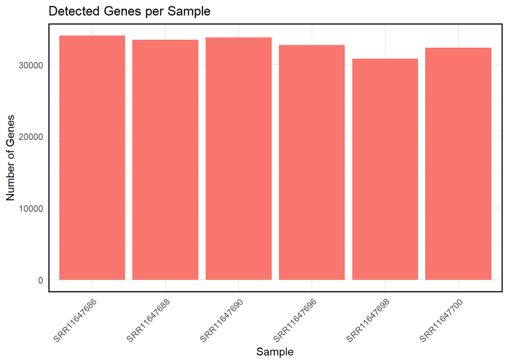

```r
qc_table_long %>%
  filter(Metric == "Detected_genes") %>%
  ggplot(aes(x = Sample, y = Value)) +
  geom_bar(stat = "identity", fill = "#F8766D") +
  theme_minimal() +
  labs(
    title = "Detected Genes per Sample",
    x = "Sample",
    y = "Number of Genes"
  ) +
  theme(
    axis.text.x = element_text(angle = 45, hjust = 1),
    panel.border = element_rect(color = "black", fill = NA, linewidth = 1)
  )
```

#2. Make a correlation plot that shows pearson correlation (using gene level data) between individual samples. (1)

```r
dds_BDA_all <- DESeqDataSetFromMatrix(
  countData = counts_protein_coding[rowSums(counts_protein_coding) >= 10, ],
  colData = coldata_BDA,
  design = ~ Type
)

vst_BDA_all <- vst(dds_BDA_all, blind = FALSE)
norm_counts_BDA <- assay(vst_BDA_all)
write.csv(norm_counts_BDA, "normalized_counts_VST.csv")
```

#3. Provide a PCA plot

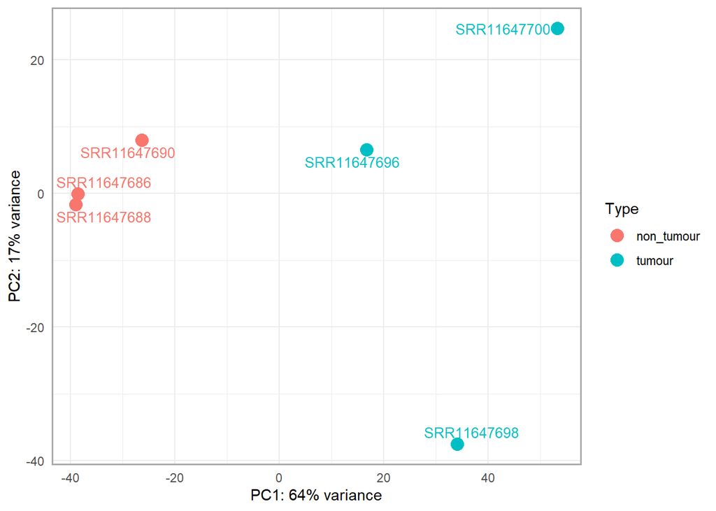

```r
library(ggrepel)
pcaData <- plotPCA(vst_BDA_all, intgroup = "Type", returnData=TRUE)
percentVar <- round(100 * attr(pcaData, "percentVar"))

ggplot(pcaData, aes(PC1, PC2, color = Type, label = name)) +
  geom_point(size = 4) +
  geom_text_repel(size = 3.5) +
  xlab(paste0("PC1: ", percentVar[1], "% variance")) +
  ylab(paste0("PC2: ", percentVar[2], "% variance")) +
  labs(color = "Type") +
  theme_minimal() +
  theme(panel.border = element_rect(color = "darkgrey", fill = NA, linewidth = 1))
```

#2. Make a correlation plot that shows pearson correlation (using gene level data) between individual samples. (2)

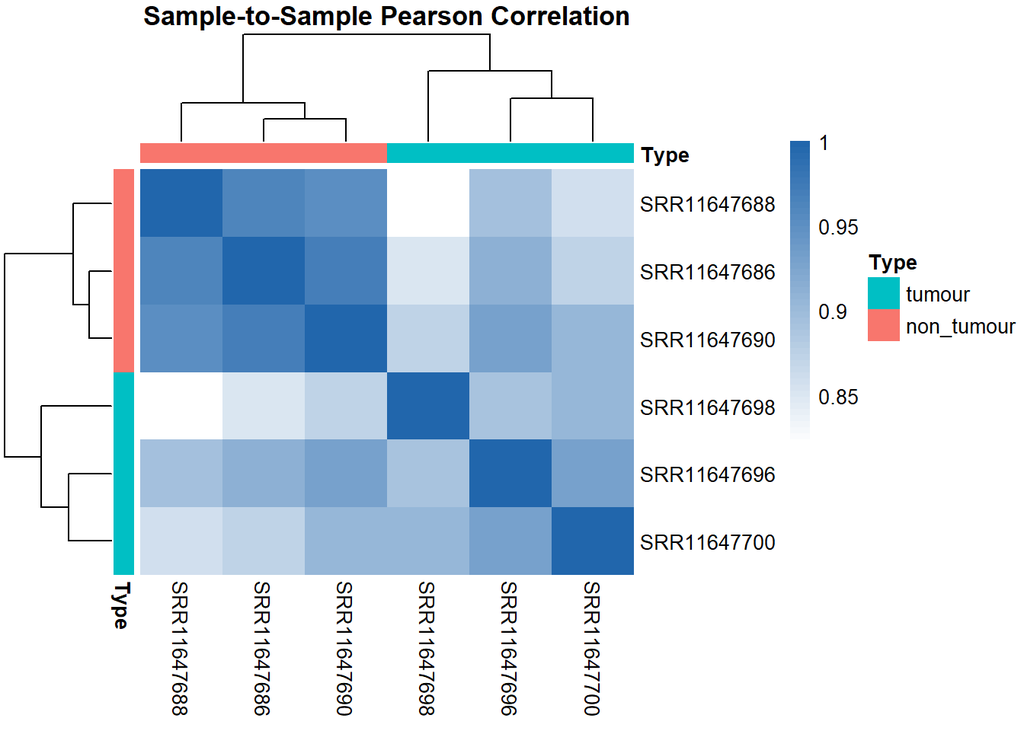

```r
library(pheatmap)
# Calculate pairwise Pearson correlations on VST counts
cor_mat  <- cor(norm_counts_BDA, method = "pearson")

# Annotation for the heatmap
anno_df <- coldata_BDA |>
  dplyr::select(Type)

# Color palette
anno_colors <- list(
  Type = c(
    tumour                 = "#00BFC4",
    non_tumour                 = "#F8766D"
  )
)

pheatmap(
  cor_mat,
  annotation_col = anno_df,
  annotation_row = anno_df,
  annotation_colors = anno_colors,
  color = colorRampPalette(c("white", "#2166AC"))(50),
  border_color = NA,
  main = "Sample-to-Sample Pearson Correlation",
  fontsize = 10
)
```

#4. Compare raw and normalized counts visually

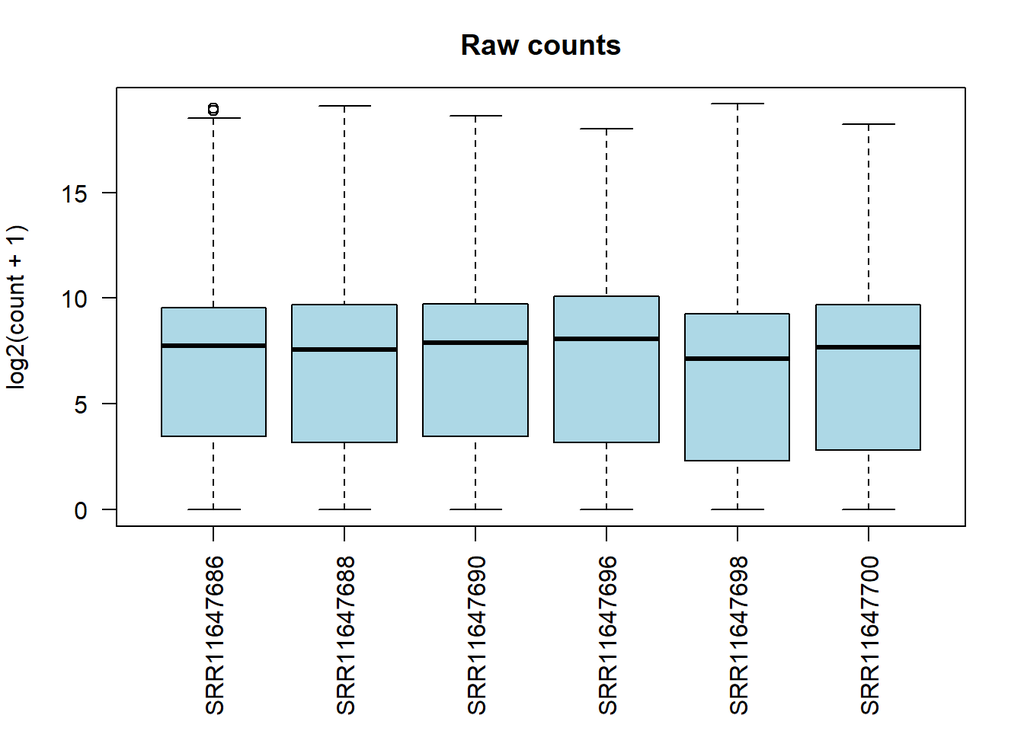

```r
par(mar = c(7, 4, 3, 2))
boxplot(log2(counts_protein_coding + 1),
        las = 2,
        col = "lightblue",
        main = "Raw counts",
        ylab = "log2(count + 1)")
```

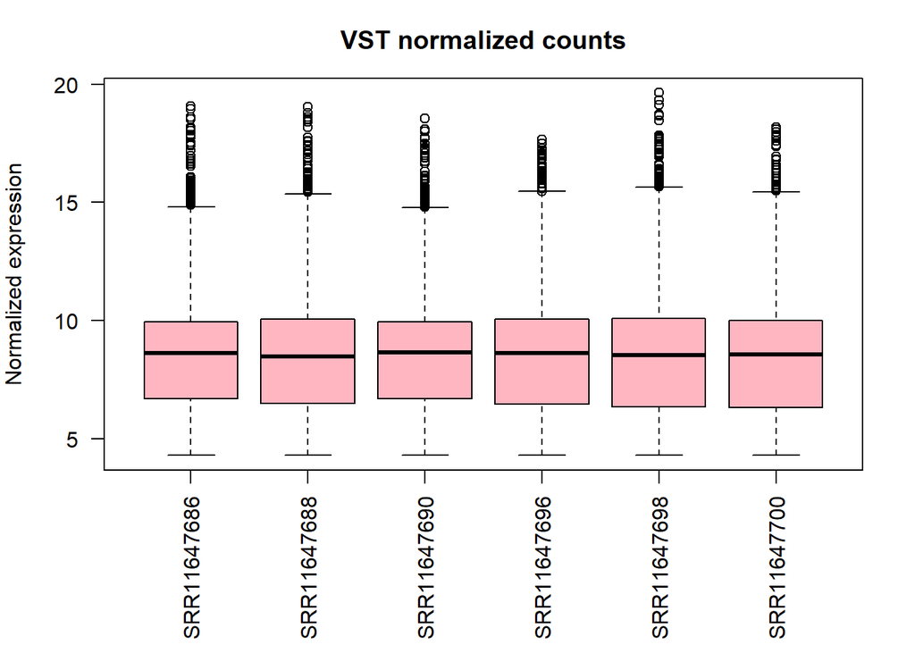

```r
par(mar = c(7, 4, 3, 2))
boxplot(assay(vst_BDA_all),
        las = 2,
        col = "lightpink",
        main = "VST normalized counts",
        ylab = "Normalized expression")
```

#5. Provide a volcano plot

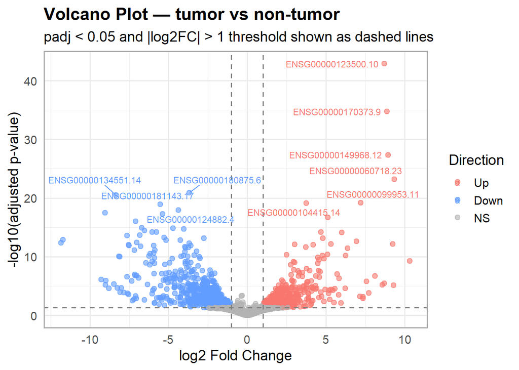

```r
volcano_df <- res_BDA_df %>%
  filter(!is.na(padj)) %>%
  mutate(negLog10Padj = -log10(padj))

top_labels <- volcano_df %>%
  filter(significance != "NS") %>%
  arrange(padj) %>%
  slice_head(n = 10)

ggplot(volcano_df, aes(x = log2FoldChange, y = negLog10Padj, color = significance)) +
  geom_point(alpha = 0.6, size = 2) +
  geom_vline(xintercept = c(-1, 1), linetype = "dashed", color = "gray50") +
  geom_hline(yintercept = -log10(0.05), linetype = "dashed", color = "gray50") +
  geom_text_repel(
    data = top_labels,
    aes(label = gene),
    size = 3,
    max.overlaps = 100,
    box.padding = 0.3
  ) +
  scale_color_manual(values = c("Up" = "#F8766D", "Down" = "#619CFF", "NS" = "grey70")) +
  labs(
    title = "Volcano Plot — tumor vs non-tumor",
    subtitle = "padj < 0.05 and |log2FC| > 1 threshold shown as dashed lines",
    x = "log2 Fold Change",
    y = "-log10(adjusted p-value)",
    color = "Direction"
  ) +
  theme_minimal(base_size = 14) +
  theme(
    panel.border = element_rect(color = "darkgray", fill = NA, linewidth = 1),
    plot.title = element_text(face = "bold")
  )
```

#6. Create/provide an MA plot

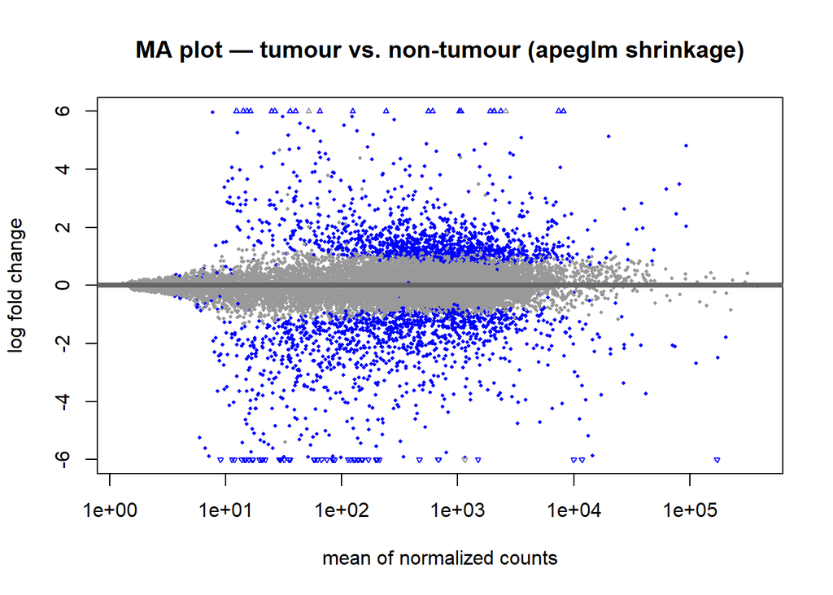

```r
DESeq2::plotMA(res_BDA_shrunk, ylim = c(-6, 6), main = "MA plot — tumour vs. non-tumour (apeglm shrinkage)")
```

```r
#DESeq2::plotMA(res_BDA, ylim = c(-6, 6), main = "MA plot — tumour vs. non-tumour (apeglm shrinkage)")
```

#7. Create/provide heatmap

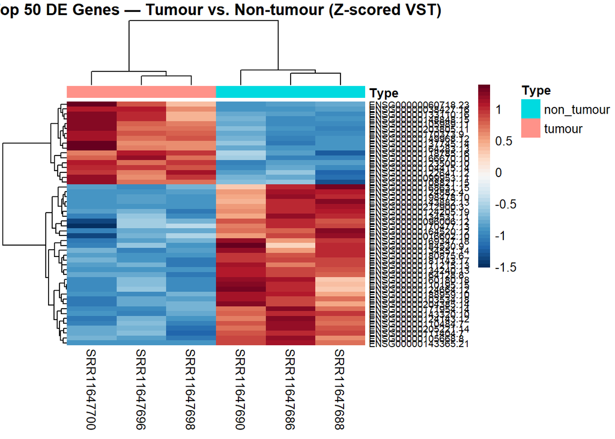

```r
# Take top 50 DE genes (by padj) for the Listerine vs Untreated comparison
top_genes <- res_BDA_df %>%
  filter(!is.na(padj)) %>%
  arrange(padj) %>%
  head(50) %>%
  pull(gene)


# Subset the VST matrix to Listerine + untreated samples only, top genes
samples_tumour_nontumour <- coldata_BDA %>%
  filter(Type %in% c("tumour", "non_tumour")) %>%
  pull(Sample)


vst_subset <- norm_counts_BDA[top_genes, samples_tumour_nontumour]

# Z-score normalize by row (gene) so we see relative expression pattern
vst_z <- t(scale(t(vst_subset)))

# Annotation
anno_subset <- coldata_BDA %>%
  filter(Sample %in% samples_tumour_nontumour) %>%
  dplyr::select(Type)


library(RColorBrewer)
pheatmap(
  vst_z,
  annotation_col  = anno_subset,
  annotation_colors = list(treatment = anno_colors$Type[c("tumour", "non_tumour")]),
  color = colorRampPalette(rev(brewer.pal(11, "RdBu")))(50),
  cluster_rows = TRUE,
  cluster_cols = TRUE,
  show_rownames = TRUE,
  fontsize_row = 8,
  border_color = NA,
  main = "Top 50 DE Genes — Tumour vs. Non-tumour (Z-scored VST)"
)
```

#8. Compare raw p-value versus adjusted p-values

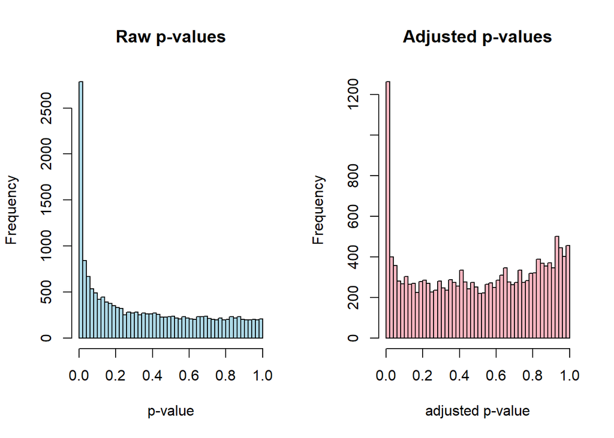

```r
par(mfrow = c(1, 2))

hist(res_BDA_df$pvalue,
     breaks = 50,
     col = "lightblue",
     main = "Raw p-values",
     xlab = "p-value")

hist(res_BDA_df$padj,
     breaks = 50,
     col = "lightpink",
     main = "Adjusted p-values",
     xlab = "adjusted p-value")
```

```r
sum(res_BDA_df$pvalue < 0.05, na.rm = TRUE)
```

```
[1] 3979
```

```r
sum(res_BDA_df$padj < 0.05, na.rm = TRUE)
```

```
[1] 1820
```

#Data biological analysis:

#1. Pick TOP 3 upregulated genes and TOP 3 downregulated genes

```r
top3_up <- res_BDA_df %>%
  filter(significance == "Up") %>%
  arrange(padj) %>%
  slice_head(n = 3)

top3_down <- res_BDA_df %>%
  filter(significance == "Down") %>%
  arrange(padj) %>%
  slice_head(n = 3)

top3_up <- merge(top3_up, protein_coding, by = 1)
top3_down <- merge(top3_down, protein_coding, by = 1)
```

#2. Perform GO over-representation analysis

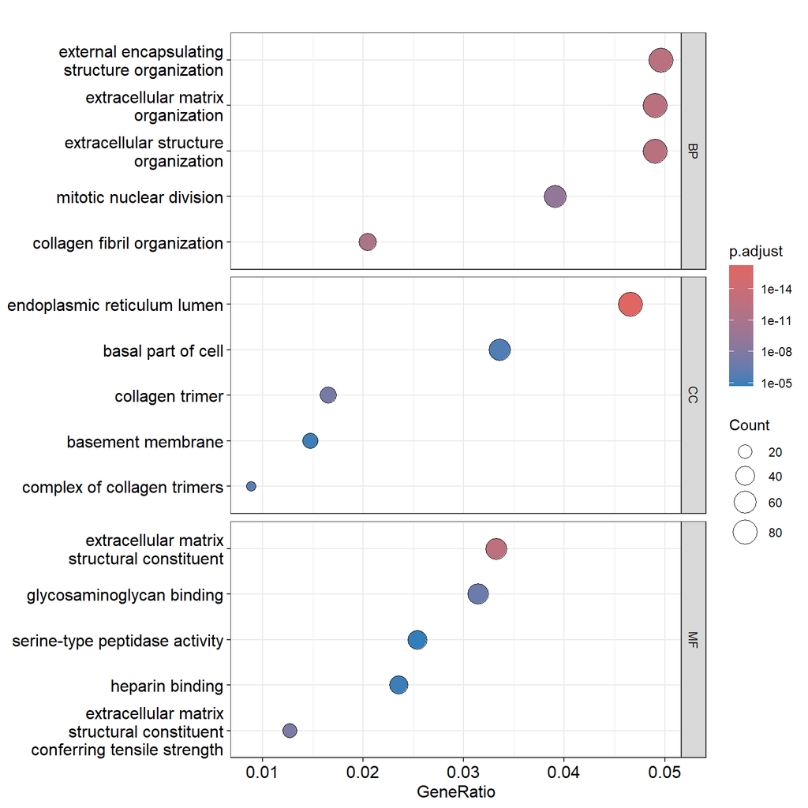

```r
sig_de <- res_BDA_df |>
  filter(padj < 0.05 & abs(log2FoldChange) > 1)
library(stringr)
sig_de$gene <- str_remove(sig_de$gene, "\\..*")

sig_de_genes <- sig_de$gene
sig_de_genes <- unique(sig_de_genes[!is.na(sig_de_genes)])

library(clusterProfiler)
library(org.Hs.eg.db)

ego_all <- enrichGO(
  gene          = sig_de_genes,
  OrgDb         = org.Hs.eg.db,
  keyType       = "ENSEMBL",
  ont           = "ALL",
  pAdjustMethod = "BH",
  pvalueCutoff  = 0.05,
  qvalueCutoff  = 0.05,
  readable      = TRUE
)

#Grafikai, kokie keliai pakite
dotplot(ego_all, showCategory = 5, split = "ONTOLOGY") + facet_grid(ONTOLOGY ~ ., scale = "free")
```

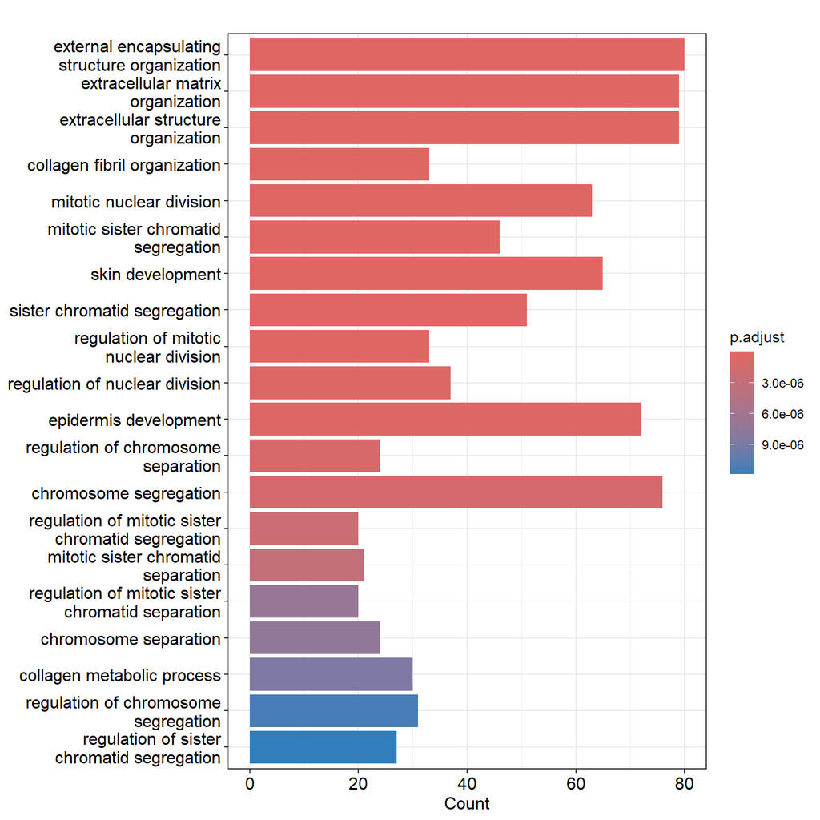

```r
barplot(ego_all, showCategory = 20)
```

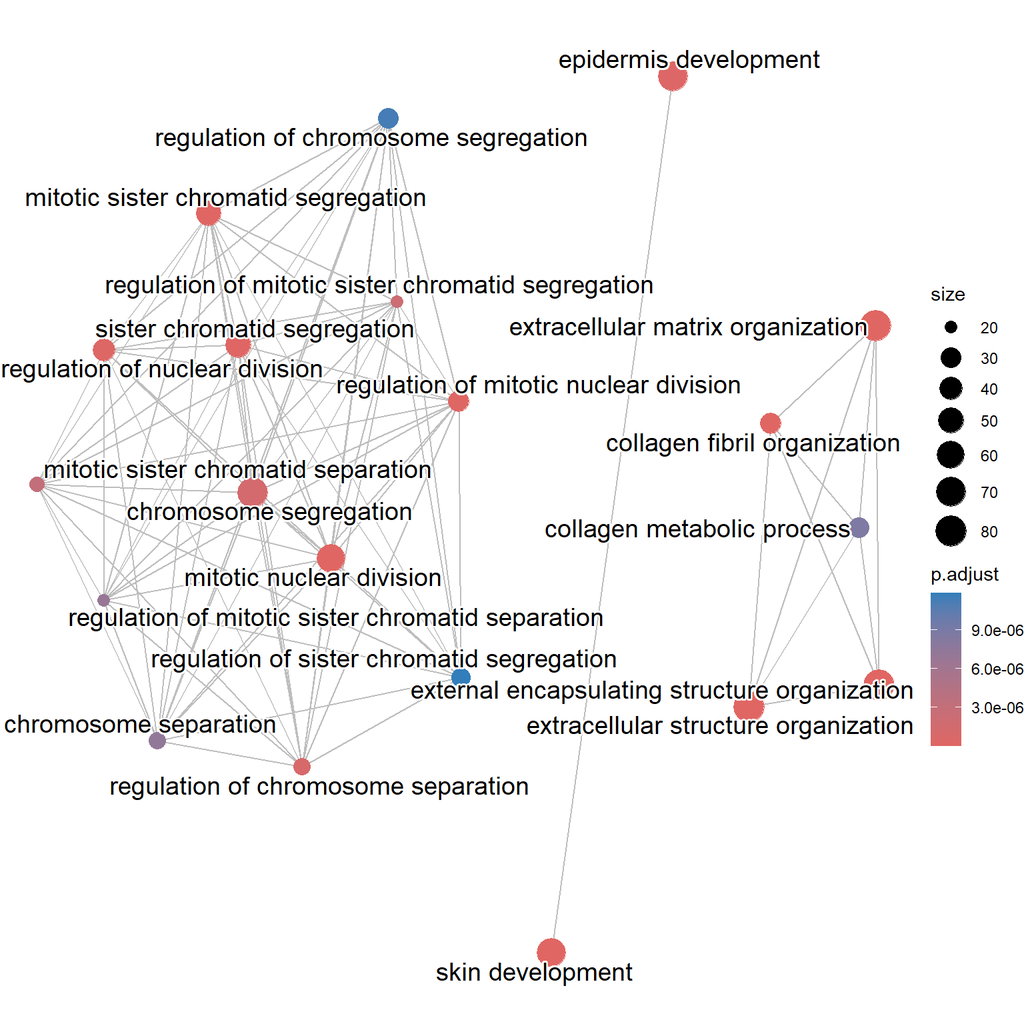

```r
library(enrichplot)
emapplot(pairwise_termsim(ego_all), showCategory = 20)
```

#2.5 KEGG

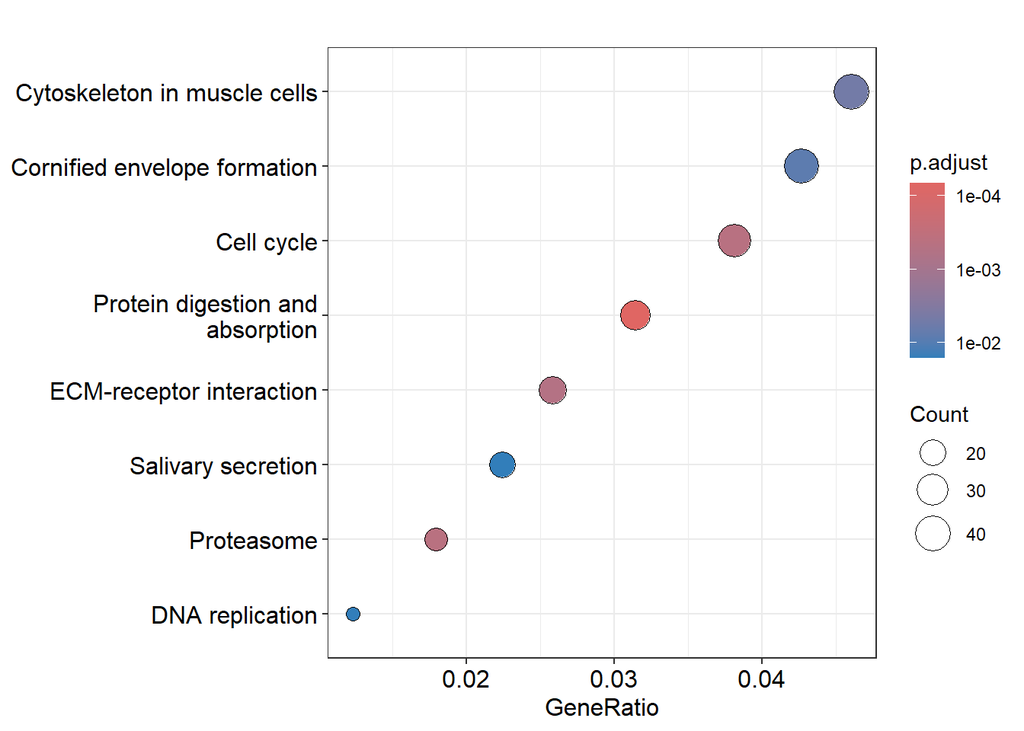

```r
kegg_df <- bitr(sig_de_genes,
                fromType = "ENSEMBL",
                toType = "ENTREZID",
                OrgDb = org.Hs.eg.db)

ekegg <- enrichKEGG(
  gene         = kegg_df$ENTREZID,
  organism     = "hsa",
  pvalueCutoff = 0.05
)

dotplot(ekegg, showCategory = 15)
```

#2.5.2 MSIGdb.

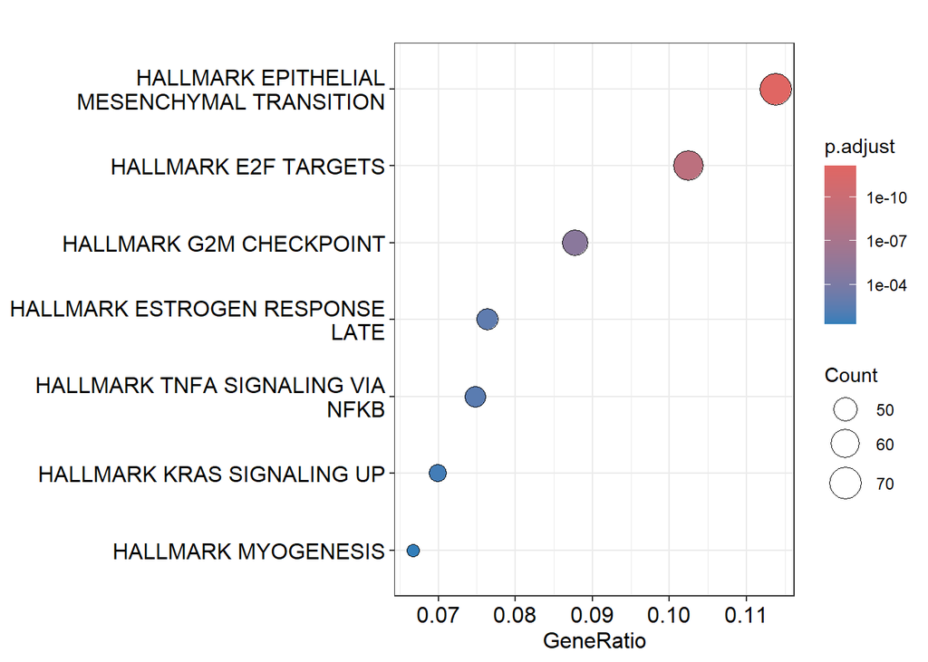

```r
library(msigdbr)
gene_map <- bitr(
  sig_de_genes,
  fromType = "ENSEMBL",
  toType   = "SYMBOL",
  OrgDb    = org.Hs.eg.db
)

sig_symbols <- unique(gene_map$SYMBOL)

hallmark_df <- msigdbr(species = "Homo sapiens", category = "H")

hallmark_list <- hallmark_df %>%
  dplyr::select(gs_name, gene_symbol) %>%
  distinct()

ehallmark <- enricher(
  gene      = sig_symbols,
  TERM2GENE = hallmark_list
)

dotplot(ehallmark, showCategory = 15)
```

#3. Using your list of genes, perform GSEA analysis over GO and MSIGdb

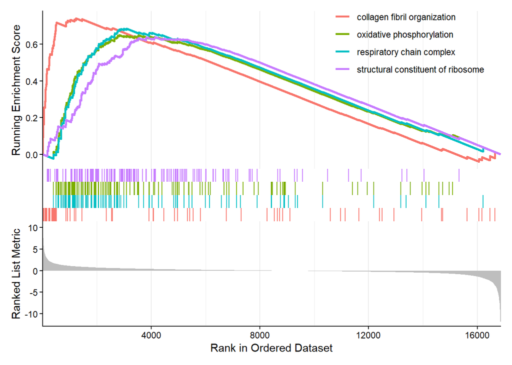

```r
library(dplyr)
library(tibble)
library(clusterProfiler)
library(org.Hs.eg.db)
library(msigdbr)
library(BiocParallel)
library(enrichplot)

# išjungia parallel backend, kad nebūtų serialize/data,node$con klaidos
BiocParallel::register(BiocParallel::SerialParam())

# paruošiam geneList GSEA analizei
gsea_geneList <- res_BDA_df %>%
  dplyr::mutate(gene = sub("\\..*", "", gene)) %>%   # pašalina ENSEMBL versijas po taško
  dplyr::filter(!is.na(gene), !is.na(log2FoldChange)) %>%
  dplyr::distinct(gene, .keep_all = TRUE) %>%
  dplyr::select(gene, log2FoldChange) %>%
  tibble::deframe() %>%
  sort(decreasing = TRUE)

# papildomi patikrinimai
gsea_geneList <- gsea_geneList[!is.na(names(gsea_geneList))]
gsea_geneList <- gsea_geneList[!duplicated(names(gsea_geneList))]
gsea_geneList <- sort(gsea_geneList, decreasing = TRUE)

# GO GSEA
gsea_go <- clusterProfiler::gseGO(
  geneList = gsea_geneList,
  OrgDb = org.Hs.eg.db,
  keyType = "ENSEMBL",
  ont = "ALL",
  pvalueCutoff = 0.05,
  verbose = FALSE
)

# MSigDB Hallmark
msig_h <- msigdbr::msigdbr(species = "Homo sapiens", category = "H") %>%
  dplyr::select(gs_name, ensembl_gene) %>%
  dplyr::filter(!is.na(ensembl_gene)) %>%
  dplyr::distinct()

gsea_hallmark <- clusterProfiler::GSEA(
  geneList = gsea_geneList,
  TERM2GENE = msig_h,
  pvalueCutoff = 0.05,
  verbose = FALSE
)

gseaplot2(gsea_go, geneSetID = 1:4)
```

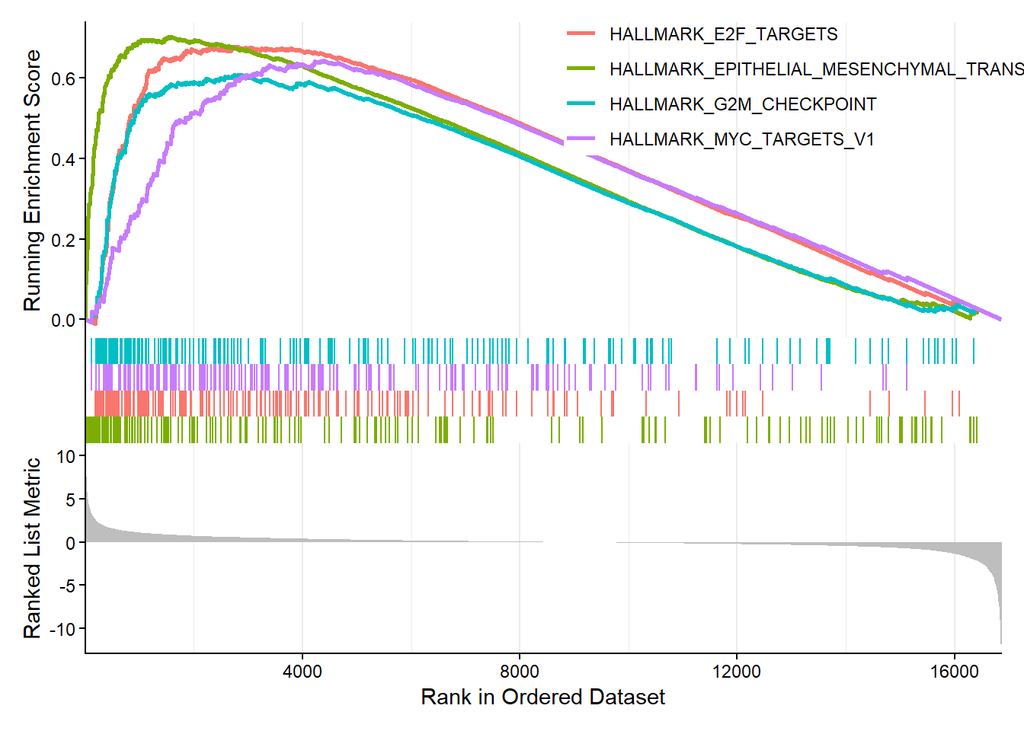

```r
gseaplot2(gsea_hallmark, geneSetID = 1:4)
```

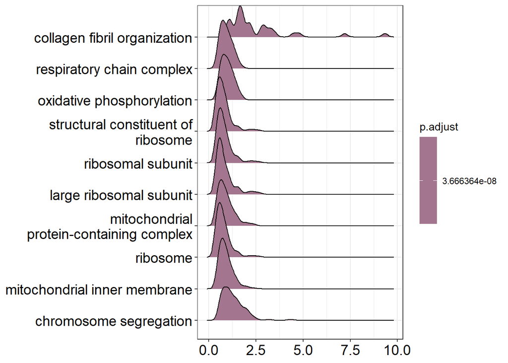

```r
ridgeplot(gsea_go, showCategory = 10)
```

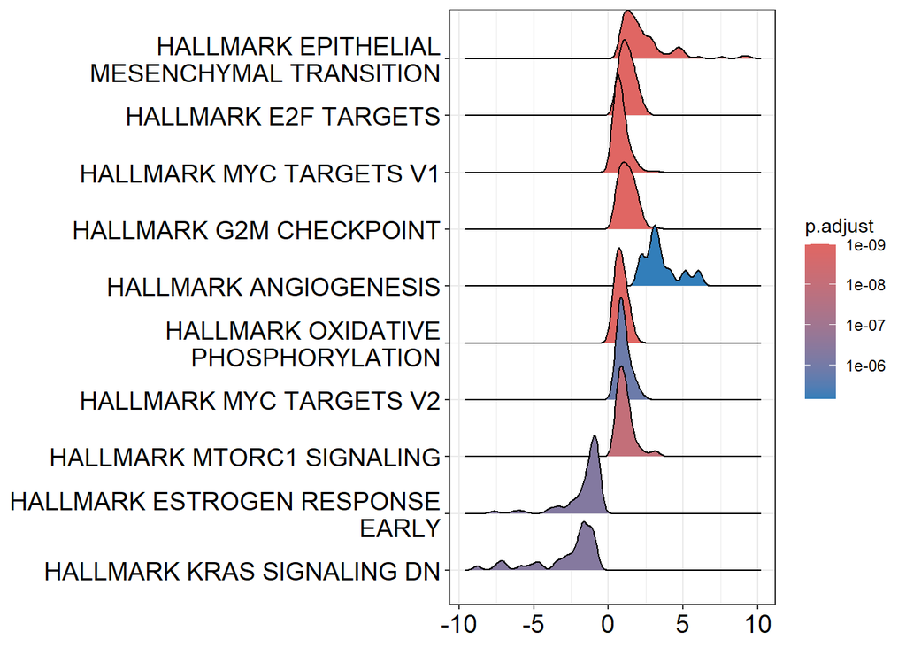

```r
ridgeplot(gsea_hallmark, showCategory = 10)
```

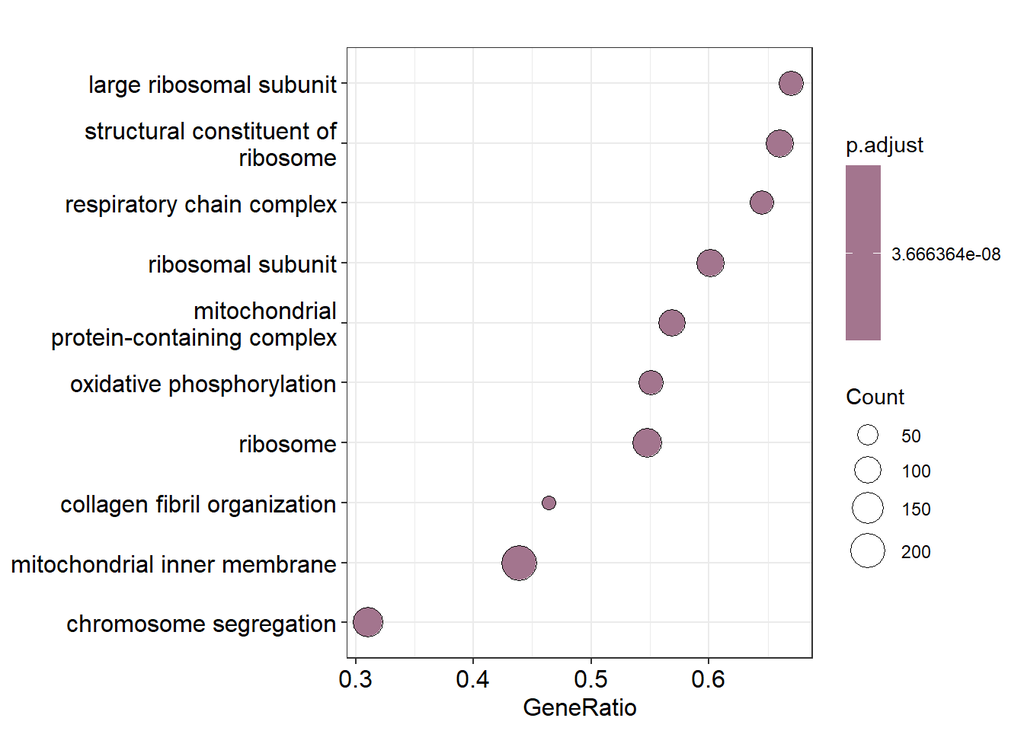

```r
dotplot(gsea_go, showCategory = 10)
```

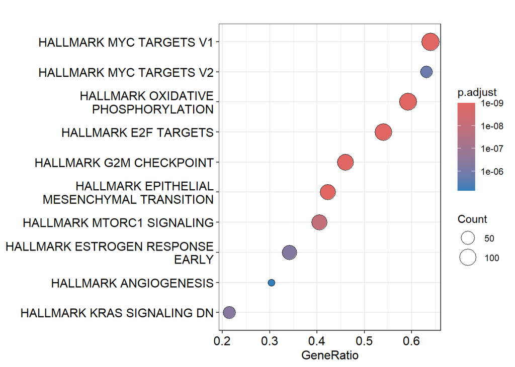

```r
dotplot(gsea_hallmark, showCategory = 10)
```

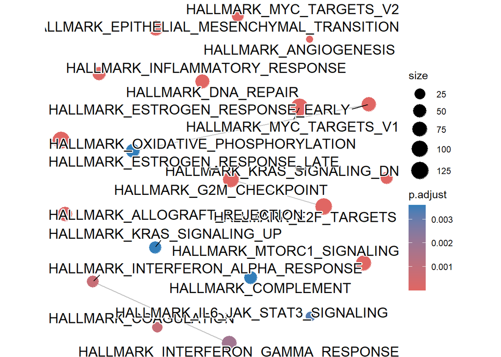

```r
#Hallmark:

gsea_hallmark <- pairwise_termsim(gsea_hallmark)

# enrichment network plot
p_hallmark <- emapplot(
  gsea_hallmark,
  showCategory = 20
)

p_hallmark
```

#4. Using aPEAR package, make a map visualisation of your GSEA results

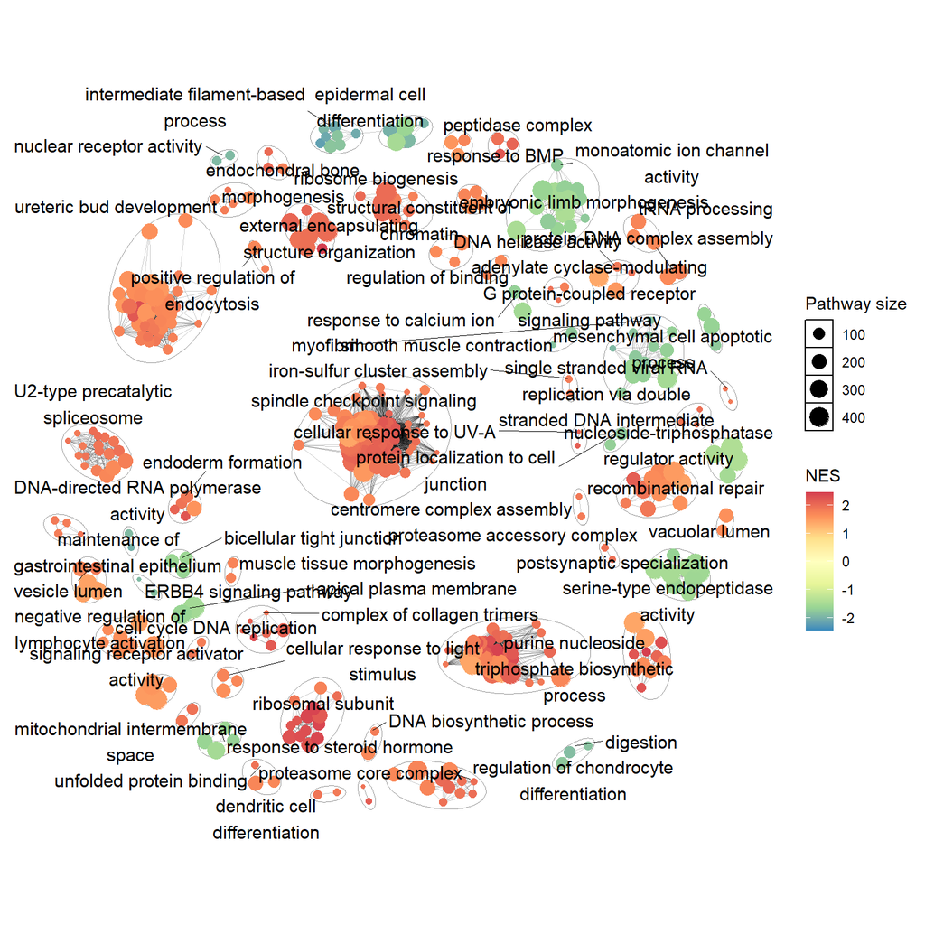

```r
library(aPEAR)

# GO GSEA map
p_go <- enrichmentNetwork(
  gsea_go@result,
  drawEllipses = TRUE,
  fontSize = 4,
  repel = TRUE
)

p_go
```

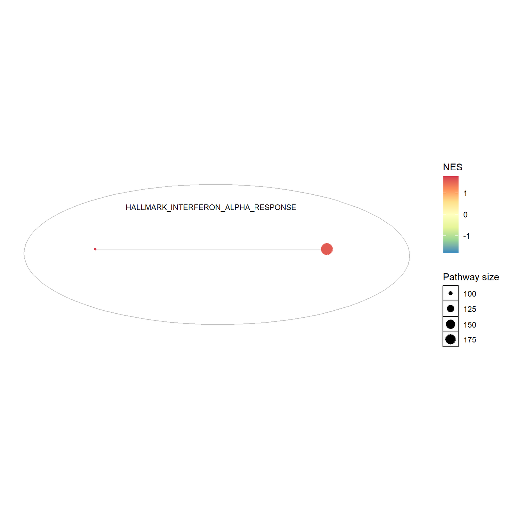

```r
p_hallmark <- enrichmentNetwork(
  gsea_hallmark@result,
  drawEllipses = TRUE,
  fontSize = 3
)

p_hallmark
```

#Feature assignment rate and mapping rate graphs

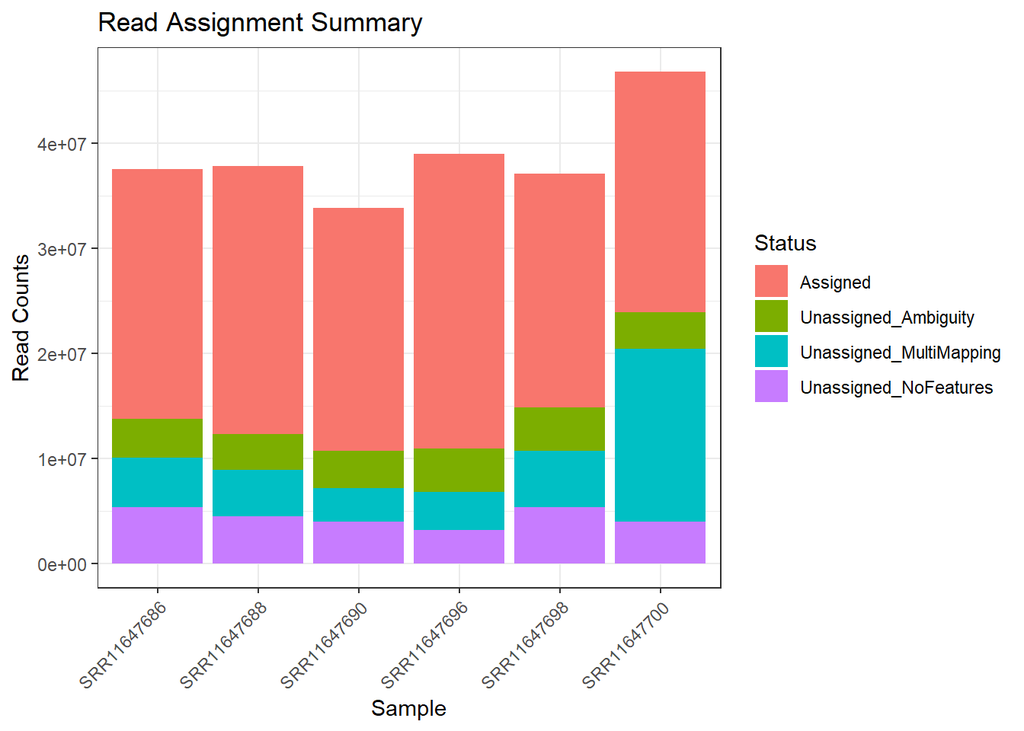

```r
# Feature assignment rates

library(ggplot2)
library(tidyverse)
library(readr)
count_table_txt <- read_table("count_table.txt.summary")
colnames(count_table_txt) <- c("Status", "SRR11647686", "SRR11647688", "SRR11647690", "SRR11647696", "SRR11647698", "SRR11647700")

count_table_filtered <- count_table_txt[rowSums(count_table_txt[,-1]) > 0, ]

count_table_txt_long <- pivot_longer(count_table_filtered, -Status,
                        names_to="Sample",
                        values_to="Count")

ggplot(count_table_txt_long, aes(x = Sample, y = Count, fill = Status)) +
  geom_bar(stat = "identity") +
  theme_bw() +
  theme(axis.text.x = element_text(angle = 45, hjust = 1)) +
  labs(title = "Read Assignment Summary",
       y = "Read Counts",
       x = "Sample")
```

[figure not shown]

```r
# Mapping rate plot

datalentele <- data.frame(
  Sample = c("SRR11647686", "SRR11647688", "SRR11647690",
             "SRR11647696", "SRR11647698", "SRR11647700"),
  Unique = c(90.04, 91.09, 89.55, 90.94, 84.94, 83.51),
  NonUnique = c(4.12, 4.02, 3.30, 3.22, 4.90, 10.59)
)

data_lonlentele <- datalentele %>%
  pivot_longer(cols = c("Unique", "NonUnique"),
               names_to = "MappingType",
               values_to = "Percentage")

data_long <- data_lonlentele %>%
  group_by(Sample) %>%
  mutate(pos = cumsum(Percentage) - (Percentage / 2))

ggplot(data_long, aes(x = Sample, y = Percentage, fill = MappingType)) +
  geom_bar(stat = "identity") +
  geom_text(aes(y = pos, label = paste0(Percentage, "%")),
            color = "grey28", size = 4) +
  labs(title = "Mapping Rate",
       x = "Sample",
       y = "Percentage of Reads (%)") +
  scale_fill_manual(values = c("Unique" = "lightblue", "NonUnique" = "lightpink"),
                    labels = c("Unique", "Non-unique")) +
  theme_minimal() +
  theme(axis.text.x = element_text(angle = 45, hjust = 1))
```